# **第六章：典型排序 – Canonical Ordination | 约束性排序**

## 6.5 线性判别分析(Linear Discriminant Analysis, LDA)

### 6.5.1 简介

线性判别分析与 RDA 和 CCA 的不同之处在于, 响应变量是将位点分组的单个变量. 这种分组可能是通过基于数据集聚类站点获得的, 或者它可以代表生态假设. LDA 试图确定一组独立的定量变量可以在多大程度上解释这种分组. 位点类型必须独立于 LDA 中使用的解释变量而获得; 否则程序将是循环的, 测试将无效. LDA 可以提供两种类型的功能: 1> 识别函数(Identification functions)从原始(非标准化)描述符获得, 并可用于查找新对象应归属的组; 2> 判别函数(Discriminant functions)是从标准化描述符计算的, 用于量化解释性变量对对象分组的相对贡献.

以下示例是从**识别**和**判别**这两方面进行的展开描述.

在进行**线性判别分析(LDA)**之前, 首先需要确保 组内数据方差齐性, 这种状况在生态学数据中很难实现. 可使用 vegan 分析包中的 betadisper() 函数进行该步分析.

lda() 是 MASS 分析包中的函数.

初始步骤: 计算组分散的均匀性(协方差齐性)和 Wilks’s lambda检验

```r
gr <- cutree(hclust(vegdist(spe.hel, "euc"), # 相异矩阵
                    "ward.D2"), # Ward 最小方差聚类分析
             k = 4) # 分成 4 组

# 只含有 3 个变量的环境数据集
env.pars2 <- as.matrix(env2[, c(1, 9, 10)])
# 使用 vegan 中的 betadisper() 验证组内协方差矩阵的(covariance matrices)多元变量同质性
env.pars2.d1 <- dist(env.pars2)
# 群体分散的多元同质性
# https://www.rdocumentation.org/packages/vegan/versions/2.4-2/topics/betadisper
(env.MHV <- betadisper(env.pars2.d1, gr))
```

```
##
##  Homogeneity of multivariate dispersions
##
## Call: betadisper(d = env.pars2.d1, group = gr)
##
## No. of Positive Eigenvalues: 3
## No. of Negative Eigenvalues: 0
##
## Average distance to median:
##       1       2       3       4
## 197.458 214.913  32.645   5.845
##
## Eigenvalues for PCoA axes:
##     PCoA1     PCoA2     PCoA3
## 2.036e+06 4.420e+02 3.149e+01
```

```r
anova(env.MHV)
```

```
## Analysis of Variance Table
##
## Response: Distances
##           Df Sum Sq Mean Sq F value   Pr(>F)
## Groups     3 226245   75415  4.9617 0.007738 **
## Residuals 25 379989   15200
## ---
## Signif. codes:  0 '***' 0.001 '**' 0.01 '*' 0.05 '.' 0.1 ' ' 1
```

```r
# https://www.rdocumentation.org/packages/vegan/versions/2.4-2/topics/anova.cca
permutest(env.MHV)  # 置换检验
```

```
##
## Permutation test for homogeneity of multivariate dispersions
## Permutation: free
## Number of permutations: 999
##
## Response: Distances
##           Df Sum Sq Mean Sq      F N.Perm Pr(>F)
## Groups     3 226245   75415 4.9617    999  0.006 **
## Residuals 25 379989   15200
## ---
## Signif. codes:  0 '***' 0.001 '**' 0.01 '*' 0.05 '.' 0.1 ' ' 1
```

> 组内协方差不齐; 对变量进行对数转换

```r
# 对数转换变量 ele & bod
env.pars3 <- cbind(log(env2$ele), env2$oxy, log(env2$bod))
colnames(env.pars3) <- c("ele.ln", "oxy", "bod.ln")
rownames(env.pars3) <- rownames(env2)
# https://www.rdocumentation.org/packages/proxy/versions/0.4-23/topics/dist
(env.pars3.d1 <- dist(env.pars3)) # 矩阵距离/相似性计算
```

```
##            1         2         3         4         5         6         7
## 2  1.9322228
## 3  1.7198298 0.6431098
## 4  1.4079115 0.8010315 1.1115304
## 5  4.2825413 2.5879468 2.5656153 3.3823744
## 6  2.1129794 1.0352522 0.5178373 1.6171197 2.2055866
## 7  1.1238067 0.8197855 0.7632224 0.5357324 3.2685740 1.2582189
## 9  5.0474285 3.2664518 3.3293836 4.0469730 0.8280439 3.0023717 3.9953045
## 10 2.2865831 0.9629253 0.6684264 1.5926962 2.0581036 0.4281992 1.3247790
## 11 0.9617106 1.4126376 1.2141469 1.0530903 3.6413184 1.5681368 0.7137886
## 12 0.6801698 2.0657401 1.8266556 1.5743309 4.3010913 2.1568961 1.2758410
## 13 0.7662291 2.2348790 2.0626296 1.6572183 4.5457386 2.4220126 1.4452080
## 14 0.8451097 2.2504643 1.9497357 1.8162393 4.3794883 2.2285008 1.4752473
## 15 0.9854953 1.6200573 1.5245771 1.1138999 3.9210191 1.9011407 0.9279237
## 16 2.1077828 0.9758694 0.9492402 1.3044286 2.5785194 1.0615195 1.1551037
## 17 2.2919278 1.3253869 1.0447935 1.7428972 2.3915260 0.8967062 1.4586320
## 18 2.1621684 1.0998158 1.0532156 1.4020151 2.6072694 1.1342320 1.2475845
## 19 1.9536290 1.2674594 1.0874657 1.4334214 2.8587970 1.1799921 1.1876214
## 20 2.2387404 1.2433538 1.1998593 1.5084376 2.6656714 1.2622819 1.3643815
## 21 3.4684693 1.9727892 1.9586348 2.5914246 1.5979170 1.6970265 2.4814664
## 22 3.4112488 1.9972191 1.9233912 2.6051266 1.6527816 1.6332401 2.4580628
## 23 6.3122472 4.7349863 4.6634955 5.4831408 2.3174671 4.2440108 5.3466302
## 24 7.2893392 5.5971266 5.6077283 6.3474900 3.1456374 5.2235641 6.2717076
## 25 8.4191466 6.7164074 6.7300537 7.4724579 4.2291929 6.3413159 7.4012327
## 26 6.2923743 4.6216270 4.6334554 5.3531209 2.2956038 4.2612264 5.2760191
## 27 5.2917718 3.6503878 3.6681681 4.3534939 1.6266009 3.3204571 4.2773528
## 28 4.4186868 2.8338257 2.8652507 3.4832712 1.5088799 2.5671753 3.4129699
## 29 3.6182986 2.2291477 2.2068106 2.7835667 1.8725910 1.9591263 2.6747100
## 30 4.3705024 2.8232490 2.8517348 3.4488187 1.6451839 2.5636619 3.3777700
##            9        10        11        12        13        14        15
## 2
## 3
## 4
## 5
## 6
## 7
## 9
## 10 2.8134086
## 11 4.3721344 1.5895017
## 12 5.0507204 2.2440660 0.7079951
```

[output cut: 61 more lines]

```
## 16
## 17
## 18
## 19
## 20
## 21
## 22
## 23
## 24 1.1371819
## 25 2.2009740 1.1425040
## 26 0.6348403 1.0577342 2.1936121
## 27 1.3254531 2.1147699 3.2516873 1.0586893
## 28 2.2285319 3.0766755 4.2128722 2.0208248 0.9624058
## 29 3.0386024 3.9585828 5.0960330 2.9031776 1.8488965 0.9048723
## 30 2.3386006 3.1891294 4.3215753 2.1316612 1.0776730 0.1620387 0.8037457
```

```r
# 群体分散的多元同质性
# https://www.rdocumentation.org/packages/vegan/versions/2.4-2/topics/betadisper
(env.MHV2 <- betadisper(env.pars3.d1, gr))
```

```
##
##  Homogeneity of multivariate dispersions
##
## Call: betadisper(d = env.pars3.d1, group = gr)
##
## No. of Positive Eigenvalues: 3
## No. of Negative Eigenvalues: 0
##
## Average distance to median:
##      1      2      3      4
## 0.9153 1.1813 1.0133 0.7599
##
## Eigenvalues for PCoA axes:
##   PCoA1   PCoA2   PCoA3
## 146.669   6.615   2.482
```

```r
# https://www.rdocumentation.org/packages/vegan/versions/2.4-2/topics/anova.cca
permutest(env.MHV2) # 置换检验
```

```
##
## Permutation test for homogeneity of multivariate dispersions
## Permutation: free
## Number of permutations: 999
##
## Response: Distances
##           Df  Sum Sq Mean Sq      F N.Perm Pr(>F)
## Groups     3  0.5325 0.17751 0.2788    999  0.843
## Residuals 25 15.9178 0.63671
```

> 组内协方差齐性 ==> 进行后续分析: Wilks’s lambda检验

```r
# 初步测试: 各组之间的解释变量均有所不同?
# Compute Wilk'S lambda test
# 第一种方法: Wilks.test() of package rrcov, χ2 test
# https://www.rdocumentation.org/packages/rrcov/versions/1.4-7/topics/Wilks.test
Wilks.test(env.pars3, gr)
```

```
##
##  One-way MANOVA (Bartlett Chi2)
##
## data:  x
## Wilks' Lambda = 0.077479, Chi2-Value = 62.665, DF = 9.000, p-value
## = 4.097e-10
## sample estimates:
##     ele.ln       oxy   bod.ln
## 1 6.464881 11.388889 1.048586
## 2 6.245804  9.944444 1.209785
## 3 5.385688  8.387500 1.557074
## 4 5.477515  5.200000 2.707430
```

```r
# 第二种方法: 多元方差分析 manova(), uses an F-test approximation
# Multivariate Analysis Of Variance
# https://www.rdocumentation.org/packages/stats/versions/3.6.0/topics/manova
(lw <-  manova(env.pars3 ~ as.factor(gr)))
```

```
## Call:
##    manova(env.pars3 ~ as.factor(gr))
##
## Terms:
##                 as.factor(gr) Residuals
## resp 1                6.32656   2.80500
## resp 2               99.23807  37.13986
## resp 3                6.75936   3.49780
## Deg. of Freedom             3        25
##
## Residual standard errors: 0.3349627 1.21885 0.3740481
## Estimated effects may be unbalanced
```

```r
summary(lw, test = "Wilks")
```

```
##               Df    Wilks approx F num Df den Df    Pr(>F)
## as.factor(gr)  3 0.077479   11.602      9 56.127 4.843e-10 ***
## Residuals     25
## ---
## Signif. codes:  0 '***' 0.001 '**' 0.01 '*' 0.05 '.' 0.1 ' ' 1
```

**示例:** 计算识别函数, 并对两个对象进行判别 (使用非标准化变量)

```r
env.pars3.df <- as.data.frame(env.pars3)
(spe.lda <- lda(gr ~ ele.ln + oxy + bod.ln,
                data = env.pars3.df))
```

```
## Call:
## lda(gr ~ ele.ln + oxy + bod.ln, data = env.pars3.df)
##
## Prior probabilities of groups:
##         1         2         3         4
## 0.3103448 0.3103448 0.2758621 0.1034483
##
## Group means:
##     ele.ln       oxy   bod.ln
## 1 6.464881 11.388889 1.048586
## 2 6.245804  9.944444 1.209785
## 3 5.385688  8.387500 1.557074
## 4 5.477515  5.200000 2.707430
##
## Coefficients of linear discriminants:
##               LD1        LD2       LD3
## ele.ln -2.5161854 -1.7232897 -1.076724
## oxy    -0.7729499 -0.2111185  0.820030
## bod.ln -0.3352012 -2.7134885  2.302602
##
## Proportion of trace:
##    LD1    LD2    LD3
## 0.9032 0.0876 0.0092
```

```r
summary(spe.lda)
```

```
##         Length Class  Mode
## prior    4     -none- numeric
## counts   4     -none- numeric
## means   12     -none- numeric
## scaling  9     -none- numeric
## lev      4     -none- character
## svd      3     -none- numeric
## N        1     -none- numeric
## call     3     -none- call
## terms    3     terms  call
## xlevels  0     -none- list
```

```r
# 展示 3 个变量的组平均值
spe.lda$means
```

```
##     ele.ln       oxy   bod.ln
## 1 6.464881 11.388889 1.048586
## 2 6.245804  9.944444 1.209785
## 3 5.385688  8.387500 1.557074
## 4 5.477515  5.200000 2.707430
```

```r
# 提取非标准化的识别函数 (matrix C, eq. 11.33 in Legendre and Legendre 2012)
(C <- spe.lda$scaling)
```

```
##               LD1        LD2       LD3
## ele.ln -2.5161854 -1.7232897 -1.076724
## oxy    -0.7729499 -0.2111185  0.820030
## bod.ln -0.3352012 -2.7134885  2.302602
```

```r
# Classification of two new objects (identification)
# A new object is created with two sites:
#     (1) ln(ele) = 6.8, oxygen = 9 and ln(bod) = 0.8
# and (2) ln(ele) = 5.5, oxygen = 10 and ln(bod) = 1.0
newo <- data.frame(c(6.8, 5.5), c(9, 10), c(0.8, 1))
colnames(newo) <- colnames(env.pars3)
# https://www.rdocumentation.org/packages/stats/versions/3.6.0/topics/predict
# 模型预测
(predict.new <- predict(spe.lda,
                        newdata = newo))
```

```
## $class
## [1] 2 3
## Levels: 1 2 3 4
##
## $posterior
##              1         2            3            4
## 1 0.1118150083 0.8879697 0.0002152868 2.067257e-09
## 2 0.0009074883 0.1115628 0.8875164034 1.328932e-05
##
## $x
##          LD1       LD2         LD3
## 1 -1.4506024 0.3725642 -2.65767398
## 2  0.9804484 1.8590247  0.02261706
```

**示例:** 计算判别函数 (使用**标准化**变量)

```r
## Computation of LDA - discrimination functions (on standardized variables)
env.pars3.sc <- as.data.frame(scale(env.pars3.df))
# https://www.rdocumentation.org/packages/MASS/versions/7.3-51.4/topics/lda
# 线性判别分析
(spe.lda2 <- lda(gr ~ .,
                data = env.pars3.sc))
```

```
## Call:
## lda(gr ~ ., data = env.pars3.sc)
##
## Prior probabilities of groups:
##         1         2         3         4
## 0.3103448 0.3103448 0.2758621 0.1034483
##
## Group means:
##       ele.ln        oxy     bod.ln
## 1  0.8192245  0.8683807 -0.5979420
## 2  0.4356034  0.2138834 -0.3316072
## 3 -1.0705312 -0.4915890  0.2421866
## 4 -0.9097337 -1.9358882  2.1428169
##
## Coefficients of linear discriminants:
##               LD1        LD2        LD3
## ele.ln -1.4369313 -0.9841282 -0.6148902
## oxy    -1.7058640 -0.4659286  1.8097674
## bod.ln -0.2028804 -1.6423383  1.3936495
##
## Proportion of trace:
##    LD1    LD2    LD3
## 0.9032 0.0876 0.0092
```

```r
# 展示对 3 个变量的组平均值
spe.lda2$means
```

```
##       ele.ln        oxy     bod.ln
## 1  0.8192245  0.8683807 -0.5979420
## 2  0.4356034  0.2138834 -0.3316072
## 3 -1.0705312 -0.4915890  0.2421866
## 4 -0.9097337 -1.9358882  2.1428169
```

```r
# 提取分类功能
(C2 <- spe.lda2$scaling)
```

```
##               LD1        LD2        LD3
## ele.ln -1.4369313 -0.9841282 -0.6148902
## oxy    -1.7058640 -0.4659286  1.8097674
## bod.ln -0.2028804 -1.6423383  1.3936495
```

```r
# 计算典型特征值 - canonical eigenvalues
spe.lda2$svd^2
```

```
## [1] 53.7489800  5.2107694  0.5495696
```

```r
# Position the objects in the space of the canonical variates
# https://www.rdocumentation.org/packages/stats/versions/3.6.0/topics/predict
# 模型预测
(Fp2 <- predict(spe.lda2)$x)
```

```
##            LD1         LD2          LD3
## 1  -4.08815044 -0.89543086  0.368898720
## 2  -2.49636282  0.46290257 -1.995979742
## 3  -2.80665900 -1.20340792 -0.404294537
## 4  -2.69030372  1.49547866 -2.201665069
## 5  -0.88032513 -2.10001776 -1.058341560
## 6  -2.51933435 -2.13278813  0.388389958
## 7  -2.90534863  0.07325368 -0.891762439
## 9   0.10226439 -1.24477119 -1.988740619
## 10 -1.50042178 -0.97923924  0.082796845
## 11 -1.88776241  0.38879240  0.504933608
## 12 -2.43269161 -0.02334372  1.335017181
## 13 -2.36586824  0.64034426  1.047951816
## 14 -2.35151544 -0.52309126  2.063049712
## 15 -1.57631023  1.28999629  0.253642431
## 16 -0.32339955  1.07828312 -0.206593726
## 17 -0.24390302 -0.22253858  1.015607242
## 18 -0.03670863  1.18429838  0.005043525
## 19 -0.14358432  0.79846455  0.706438420
## 20  0.34613069  1.44649809  0.168867743
## 21  1.44366762  0.83715738  0.075338523
## 22  1.39156272  0.44176082  0.553687749
## 23  3.22449723 -2.24592686  1.121189781
## 24  4.22284240 -1.19768740 -0.421150517
## 25  5.07721362 -1.72223580 -0.573395210
## 26  3.85732159 -0.32609931 -0.218185612
## 27  3.29605050  0.46595399 -0.152685529
## 28  2.85126117  1.28352918 -0.130333375
## 29  2.33854423  1.39018587  0.517216834
## 30  3.09729316  1.53967878  0.035057848
```

```r
# 替代方法:  Fp2 <- as.matrix(env.pars3.sc) %*% C2
# 对象的分类
# 模型预测 predict
# https://www.rdocumentation.org/packages/stats/versions/3.6.0/topics/predict
(spe.class2 <- predict(spe.lda2)$class)
```

```
##  [1] 1 2 1 2 2 1 1 2 2 1 1 1 1 2 2 2 2 2 2 3 3 4 4 4 3 3 3 3 3
## Levels: 1 2 3 4
```

```r
# 属于该组的后验概率
# (rounded for easier interpretation)
(spe.post2 <- round(predict(spe.lda2)$posterior, 2))
```

```
##       1    2    3    4
## 1  0.99 0.01 0.00 0.00
## 2  0.49 0.51 0.00 0.00
## 3  0.86 0.14 0.00 0.00
## 4  0.48 0.52 0.00 0.00
## 5  0.19 0.81 0.00 0.00
## 6  0.88 0.12 0.00 0.00
## 7  0.80 0.20 0.00 0.00
## 9  0.02 0.97 0.01 0.00
## 10 0.48 0.52 0.00 0.00
## 11 0.61 0.39 0.00 0.00
## 12 0.87 0.13 0.00 0.00
## 13 0.81 0.19 0.00 0.00
## 14 0.91 0.09 0.00 0.00
## 15 0.40 0.60 0.00 0.00
## 16 0.06 0.89 0.05 0.00
## 17 0.14 0.83 0.03 0.00
## 18 0.04 0.83 0.13 0.00
## 19 0.08 0.83 0.09 0.00
## 20 0.02 0.56 0.42 0.00
## 21 0.00 0.06 0.94 0.00
## 22 0.00 0.08 0.92 0.00
## 23 0.00 0.00 0.02 0.98
## 24 0.00 0.00 0.05 0.95
## 25 0.00 0.00 0.00 1.00
## 26 0.00 0.00 0.52 0.48
## 27 0.00 0.00 0.96 0.04
## 28 0.00 0.00 1.00 0.00
## 29 0.00 0.00 1.00 0.00
## 30 0.00 0.00 1.00 0.00
```

```r
# 列联表 - 先验 prior vs 预测分类 predicted classifications
(spe.table2 <- table(gr, spe.class2))
```

```
##    spe.class2
## gr  1 2 3 4
##   1 7 2 0 0
##   2 1 8 0 0
##   3 0 1 7 0
##   4 0 0 0 3
```

```r
# 正确分类的百分比
# ?diag - 矩阵对角线
# prop.table - Express Table Entries As Fraction Of Marginal Table
# 快速表条目作为边际表的分数
# https://www.rdocumentation.org/packages/base/versions/3.6.0/topics/prop.table
diag(prop.table(spe.table2, 1))
```

```
##         1         2         3         4
## 0.7777778 0.8888889 0.8750000 1.0000000
```

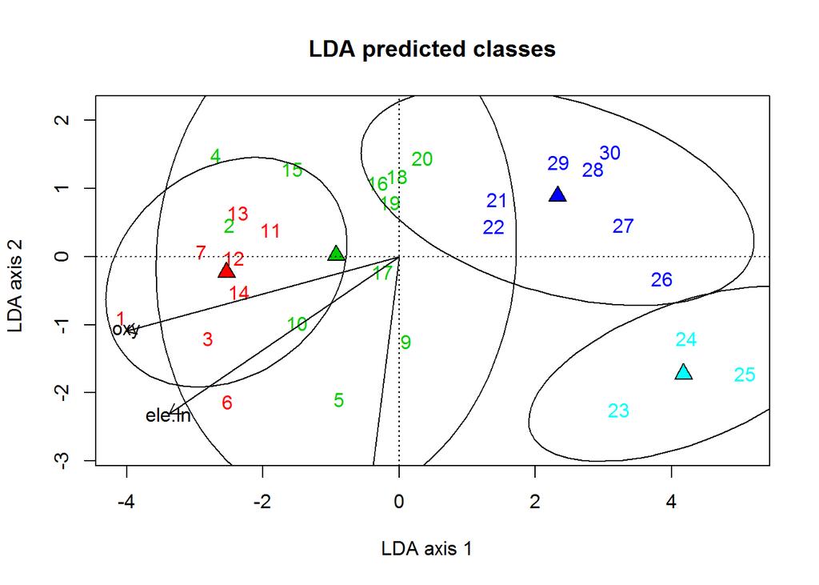

```r
# Plot the LDA results using the homemade function plot.lda()
plot.lda(lda.out = spe.lda2,
  groups = gr,
  plot.sites = 2,
  plot.centroids = 1,
  mul.coef = 2.35
  )
```

**线性判别分析 - 留一交叉验证**

```r
# LDA with jackknife-based classification (i.e., leave-one-out cross-validation)
# https://www.rdocumentation.org/packages/MASS/versions/7.3-51.4/topics/lda
(spe.lda.jac <-
  lda(gr ~ ele.ln + oxy + bod.ln,
      data = env.pars3.sc,
      CV = TRUE))
```

```
## $class
##  [1] 1 2 1 1 2 1 1 2 2 1 1 1 1 1 2 2 2 2 2 3 3 4 4 4 4 3 3 3 3
## Levels: 1 2 3 4
##
## $posterior
##               1            2            3            4
## 1  9.856551e-01 1.434492e-02 1.624524e-10 2.268885e-16
## 2  2.050764e-01 7.949098e-01 1.378657e-05 1.540131e-11
## 3  8.261711e-01 1.738285e-01 4.676343e-07 3.608677e-11
## 4  9.294667e-01 7.053320e-02 1.308816e-07 1.938157e-18
## 5  3.602902e-01 6.393106e-01 3.743456e-04 2.484465e-05
## 6  9.920760e-01 7.924018e-03 1.433556e-09 1.329144e-11
## 7  7.503863e-01 2.496124e-01 1.301140e-06 2.187651e-12
## 9  2.538900e-02 9.237953e-01 4.990850e-02 9.072389e-04
## 10 4.089566e-01 5.908892e-01 1.541631e-04 2.275813e-08
## 11 5.754393e-01 4.244414e-01 1.192512e-04 6.709393e-10
## 12 8.449723e-01 1.550174e-01 1.032996e-05 5.502328e-11
## 13 7.722571e-01 2.277145e-01 2.847237e-05 3.131333e-11
## 14 8.670349e-01 1.329529e-01 1.217565e-05 2.906574e-10
## 15 5.107470e-01 4.881860e-01 1.067062e-03 3.168917e-10
## 16 7.462310e-02 8.626828e-01 6.269307e-02 1.044653e-06
## 17 1.911746e-01 7.565109e-01 5.229360e-02 2.087830e-05
## 18 4.672327e-02 7.629319e-01 1.903407e-01 4.103453e-06
## 19 9.984251e-02 7.606609e-01 1.394906e-01 6.011895e-06
## 20 1.461319e-02 8.000947e-01 1.852909e-01 1.217060e-06
## 21 3.707675e-04 7.077979e-02 9.282315e-01 6.179838e-04
## 22 7.761427e-04 1.023079e-01 8.952827e-01 1.633273e-03
## 23 3.806558e-07 3.687605e-04 1.441692e-01 8.554617e-01
## 24 7.350652e-10 7.029675e-06 8.107338e-02 9.189196e-01
## 25 4.550816e-13 3.261697e-08 6.661366e-03 9.933386e-01
## 26 1.196103e-09 2.185038e-05 2.948191e-01 7.051590e-01
## 27 6.972776e-08 2.871567e-04 9.501713e-01 4.954145e-02
## 28 3.224015e-07 6.511064e-04 9.965213e-01 2.827259e-03
## 29 4.358690e-06 2.456081e-03 9.967601e-01 7.794545e-04
## 30 5.772567e-08 1.968661e-04 9.973528e-01 2.450247e-03
##
## $terms
## gr ~ ele.ln + oxy + bod.ln
## attr(,"variables")
## list(gr, ele.ln, oxy, bod.ln)
```

[output cut: 13 more lines]

```
## [1] 1
## attr(,".Environment")
## <environment: R_GlobalEnv>
## attr(,"predvars")
## list(gr, ele.ln, oxy, bod.ln)
## attr(,"dataClasses")
##        gr    ele.ln       oxy    bod.ln
## "numeric" "numeric" "numeric" "numeric"
##
## $call
## lda(formula = gr ~ ele.ln + oxy + bod.ln, data = env.pars3.sc,
##     CV = TRUE)
##
## $xlevels
## named list()
```

```r
summary(spe.lda.jac)
```

```
##           Length Class  Mode
## class      29    factor numeric
## posterior 116    -none- numeric
## terms       3    terms  call
## call        4    -none- call
## xlevels     0    -none- list
```

```r
# 正确分类的数量和比例 - 列联表
spe.jac.class <- spe.lda.jac$class
(spe.jac.table <- table(gr, spe.jac.class)) # 列联表
```

```
##    spe.jac.class
## gr  1 2 3 4
##   1 7 2 0 0
##   2 3 6 0 0
##   3 0 1 6 1
##   4 0 0 0 3
```

```r
# 分类成功
# ?diag - 矩阵对角线
# prop.table - Express Table Entries As Fraction Of Marginal Table
# 快速表条目作为边际表的分数
# https://www.rdocumentation.org/packages/base/versions/3.6.0/topics/prop.table
diag(prop.table(spe.jac.table, 1))
```

```
##         1         2         3         4
## 0.7777778 0.6666667 0.7500000 1.0000000
```

以上演示仅为示例展示应用. 运行具有非标准化解释变量的函数允许对新对象进行分类, 同时产生与标准化变量运行完全相同的区分(判别).

```r
# 不在本书中 -->>
# 示例数据
grY <- c(1, 1, 1, 2, 2, 3, 3)
x1 <- c(1, 2, 2, 8, 8, 8, 9)
x2 <- c(2, 2, 1, 7, 6, 3, 3)
X <- as.data.frame(cbind(x1, x2))

# 非标准化识别函数的计算 - Computation of unstandardized identification functions
(unstand.lda <- lda(grY ~ .,
                   data = X))
```

```
## Call:
## lda(grY ~ ., data = X)
##
## Prior probabilities of groups:
##         1         2         3
## 0.4285714 0.2857143 0.2857143
##
## Group means:
##         x1       x2
## 1 1.666667 1.666667
## 2 8.000000 6.500000
## 3 8.500000 3.000000
##
## Coefficients of linear discriminants:
##          LD1        LD2
## x1 -1.760775 -0.7956161
## x2 -1.265529  1.4600579
##
## Proportion of trace:
##    LD1    LD2
## 0.9313 0.0687
```

```r
# 标准化判别函数的计算 - Computation of standardized discriminant functions
X.sc <- as.data.frame(scale(X))
(stand.lda <- lda(grY ~ .,
                 data = X.sc))
```

```
## Call:
## lda(grY ~ ., data = X.sc)
##
## Prior probabilities of groups:
##         1         2         3
## 0.4285714 0.2857143 0.2857143
##
## Group means:
##           x1         x2
## 1 -1.0589965 -0.7917269
## 2  0.7238710  1.3801726
## 3  0.8646237 -0.1925822
##
## Coefficients of linear discriminants:
##          LD1       LD2
## x1 -6.254853 -2.826291
## x2 -2.816302  3.249205
##
## Proportion of trace:
##    LD1    LD2
## 0.9313 0.0687
```

```r
# <<--不在本书中
```

## 6.6 其他的非对称分析(Asymmetric Analyses)

上述介绍的内容中并不包括所有可能的多元分析模型.

### 6.6.1 主响应曲线(Principal Response Curves, PRC)

*https://link.springer.com/article/10.1007/s10452-016-9604-1** http://edild.github.io/prc1/* *https://www.youtube.com/watch?v=-EOZkJTXn7U*

通过跟踪试验中对照与处理之间的差异随时间的变化, 分析处理产生的影响. 可以图形展示的方式表现群落和物种水平产生的效应. vegan 工具包中 prc() 函数.

以往的单因素研究思路已经不能完全适应现在的多因素实验设计的群落生态学研究.

主响应曲线侧重于对照和处理之间的差异.

```r
# 导入数据 (vegan 内置)
data(pyrifos)
head(pyrifos)
```

```
##        Simve Daplo Cerpu Alogu Aloco Alore Aloaf Copsp Ostsp Slyla Acrha
## w.4.c1 3.951     0     0     0     0     0     0 2.773 0.000 1.386 0.000
## w.4.c2 2.303     0     0     0     0     0     0 2.079 0.000 0.000 1.099
## w.4.c3 4.595     0     0     0     0     0     0 3.761 0.000 0.693 0.000
## w.4.c4 2.398     0     0     0     0     0     0 3.296 0.693 0.000 0.000
## w.4.c5 4.025     0     0     0     0     0     0 3.466 0.000 0.000 1.609
## w.4.c6 2.303     0     0     0     0     0     0 2.197 0.000 0.000 0.693
##        Aloex Chysp Alona Plead Oxyte Grate Copdi NauLa  CilHa  Strvi amosp
## w.4.c1     0 1.946     0 0.000     0     0 4.615 8.594 13.441  9.269 0.000
## w.4.c2     0 0.000     0 0.000     0     0 0.000 5.994 11.233  7.091 5.994
## w.4.c3     0 2.639     0 0.000     0     0 0.000 7.824 11.823  9.170 0.000
## w.4.c4     0 1.386     0 0.000     0     0 0.000 6.552 13.193  5.303 6.686
## w.4.c5     0 0.693     0 1.099     0     0 0.000 7.784 11.702  7.864 7.091
## w.4.c6     0 0.693     0 0.000     0     0 0.000 6.217 11.672 10.166 5.994
##        Ascmo Synsp Squro Squmu Polar Kerqu Anufi Mytve Mytvi Mytmu Lepsp
## w.4.c1 0.000 6.217     0     0 6.217     0     0     0 4.615     0 0.000
## w.4.c2 6.552 8.367     0     0 4.615     0     0     0 0.000     0 0.000
## w.4.c3 5.303 7.245     0     0 8.040     0     0     0 0.000     0 5.707
## w.4.c4 0.000 5.994     0     0 8.390     0     0     0 0.000     0 5.303
## w.4.c5 0.000 6.686     0     0 0.000     0     0     0 0.000     0 0.000
## w.4.c6 6.804 6.399     0     0 9.787     0     0     0 0.000     0 0.000
##        Leppa Colob Colbi Colun Lecsp Lecqu Lecco Leclu Lecfl Tripo Cepsp
## w.4.c1 0.000 4.615 0.000     0 0.000 0.000 0.000     0 4.615     0 0.000
## w.4.c2 5.303 0.000 0.000     0 0.000 4.615 0.000     0 0.000     0 0.000
## w.4.c3 4.615 4.615 5.303     0 4.615 0.000 0.000     0 5.303     0 0.000
## w.4.c4 0.000 0.000 5.303     0 0.000 4.615 0.000     0 0.000     0 5.303
## w.4.c5 0.000 0.000 0.000     0 5.303 0.000 0.000     0 0.000     0 5.994
## w.4.c6 0.000 4.615 0.000     0 0.000 0.000 4.615     0 0.000     0 0.000
##        Monlo Monae Scalo Trilo Tripo.1 Tricy Trisp Tepat Rotne Notla Filsp
## w.4.c1     0     0     0     0       0     0     0     0     0     0     0
## w.4.c2     0     0     0     0       0     0     0     0     0     0     0
## w.4.c3     0     0     0     0       0     0     0     0     0     0     0
## w.4.c4     0     0     0     0       0     0     0     0     0     0     0
## w.4.c5     0     0     0     0       0     0     0     0     0     0     0
## w.4.c6     0     0     0     0       0     0     0     0     0     0     0
##        Lopox hydrspec bothrosp olchaeta erpoocto glsicomp alglhete
## w.4.c1     0        0    0.000    4.034    4.529     0.00    3.858
## w.4.c2     0        0    2.353    4.986    4.621     0.00    3.644
## w.4.c3     0        0    2.353    5.497    3.858     0.00    4.706
## w.4.c4     0        0    3.370    6.387    4.426     0.00    3.644
```

[output cut: 106 more lines]

```
## w.4.c6    0.000    2.566        0        0    0.000        0        0
##        holodubi holopici leceriae lilurhom monaangu mystazur mystloni
## w.4.c1    0.000    2.353        0    0.000    2.353        0    2.987
## w.4.c2    0.000    2.353        0    0.000    4.312        0    4.529
## w.4.c3    0.000    0.000        0    2.353    0.000        0    4.312
## w.4.c4    0.000    4.183        0    0.000    0.000        0    4.923
## w.4.c5    0.000    0.000        0    2.353    2.353        0    5.997
## w.4.c6    2.353    4.183        0    0.000    0.000        0    3.858
##        oecefurv oecelacu triabico paponysp
## w.4.c1        0        0        0        0
## w.4.c2        0        0        0        0
## w.4.c3        0        0        0        0
## w.4.c4        0        0        0        0
## w.4.c5        0        0        0        0
## w.4.c6        0        0        0        0
```

```r
# 创建时间因子和处理因子 - time (week) & treatment (dose).
# 创建附加因子 - "ditch", 表示'围格', 用与测试目的
week <-
  gl(11, 12,
     labels = c(-4, -1, 0.1, 1, 2, 4, 8, 12, 15, 19, 24))
dose <-
  factor(rep(c(0.1, 0, 0, 0.9, 0, 44, 6, 0.1, 44, 0.9, 0, 6),
         11))
ditch <- gl(12, 1, length = 132)

# Modified RDA - 调整过的冗余分析
# ?prc - Principal Response Curves, PRC 主响应曲线 / vegan 工具包
# 冗余分析的特例
(mod <- prc(pyrifos, dose, week))
```

```
## Call: prc(response = pyrifos, treatment = dose, time = week)
##
##                Inertia Proportion Rank
## Total         288.9920     1.0000
## Conditional    63.3493     0.2192   10
## Constrained    96.6837     0.3346   44
## Unconstrained 128.9589     0.4462   77
## Inertia is variance
##
## Eigenvalues for constrained axes:
##   RDA1   RDA2   RDA3   RDA4   RDA5   RDA6   RDA7   RDA8   RDA9  RDA10
## 25.282  8.297  6.044  4.766  4.148  3.857  3.587  3.334  3.087  2.551
##  RDA11  RDA12  RDA13  RDA14  RDA15  RDA16  RDA17  RDA18  RDA19  RDA20
##  2.466  2.209  2.129  1.941  1.799  1.622  1.579  1.440  1.398  1.284
##  RDA21  RDA22  RDA23  RDA24  RDA25  RDA26  RDA27  RDA28  RDA29  RDA30
##  1.211  1.133  1.001  0.923  0.862  0.788  0.750  0.712  0.685  0.611
##  RDA31  RDA32  RDA33  RDA34  RDA35  RDA36  RDA37  RDA38  RDA39  RDA40
##  0.584  0.537  0.516  0.442  0.417  0.404  0.368  0.340  0.339  0.306
##  RDA41  RDA42  RDA43  RDA44
##  0.279  0.271  0.205  0.179
##
## Eigenvalues for unconstrained axes:
##    PC1    PC2    PC3    PC4    PC5    PC6    PC7    PC8
## 17.156  9.189  7.585  6.064  5.730  4.843  4.518  4.105
## (Showing 8 of 77 unconstrained eigenvalues)
```

```r
summary(mod)
```

```
##
## Call:
## prc(response = pyrifos, treatment = dose, time = week)
## Species scores:
##     Simve     Daplo     Cerpu     Alogu     Aloco     Alore     Aloaf
## -1.461934 -0.796510 -0.295171 -0.152301 -0.096273 -0.171335 -0.231967
##     Copsp     Ostsp     Slyla     Acrha     Aloex     Chysp     Alona
## -0.635966 -1.257492  0.302872 -0.057396 -0.124049 -0.051689 -0.034638
##     Plead     Oxyte     Grate     Copdi     NauLa     CilHa     Strvi
## -0.075268 -0.013815 -0.052667 -0.777088 -2.636100 -0.486881 -1.669474
##     amosp     Ascmo     Synsp     Squro     Squmu     Polar     Kerqu
##  0.738371 -0.037926  0.014409 -0.143790  0.246185 -0.251255 -0.269397
##     Anufi     Mytve     Mytvi     Mytmu     Lepsp     Leppa     Colob
## -0.235362 -0.040448 -0.049452 -0.057589 -0.542922 -0.046123  0.393234
##     Colbi     Colun     Lecsp     Lecqu     Lecco     Leclu     Lecfl
##  0.075905  0.450495 -0.257170  0.048327  0.158007 -0.027077  0.221912
##     Tripo     Cepsp     Monlo     Monae     Scalo     Trilo   Tripo.1
## -0.117056  0.440303  0.287108  0.048918  0.041981  0.021257 -0.134025
##     Tricy     Trisp     Tepat     Rotne     Notla     Filsp     Lopox
## -0.182409 -0.042651 -0.004198 -0.078168  0.062163  0.091561  0.016854
##  hydrspec  bothrosp  olchaeta  erpoocto  glsicomp  alglhete  hebdstag
##  0.026485 -0.216815  0.633674  0.490029  0.078527  0.039728 -0.490678
##   sphidae  ansuvote  armicris  bathcont  binitent  gyraalbu  hippcomp
## -0.796015 -0.076512 -0.913681 -0.039855  1.060788 -0.017975 -0.219974
##  lymnstag  lymnaes7  physfont  plbacorn  popyanti  radiovat  radipere
##  0.143403 -0.073502  0.014349 -0.046098 -0.691904  0.010777  0.340163
##  valvcris  valvpisc  hycarina  gammpule  aselaqua  proameri  collembo
## -0.005753  0.145523 -0.567803 -0.830166 -0.858606 -0.063401 -0.016264
##  caenhora  caenluct  caenrobu  cloedipt  cloesimi  aeshniae  libellae
## -3.136867 -1.292300 -0.068624 -2.574625 -0.675580 -0.115677  0.044524
##  conagrae  corident  coripanz  coripunc  cymabons  hesplinn  hespsahl
## -0.886795 -0.007484 -0.065501  0.096124 -0.025213  0.037779 -0.018078
##  notoglau  notomacu  notoobli  notoviri  pacoconc  pleaminu  sigadist
## -0.301948 -0.027226 -0.044790 -0.117398 -0.009087 -0.038705 -0.041594
##  sigafall  sigastri  sigarasp  colyfusc  donacis6  gyrimari  haliconf
##  0.009987 -0.032743  0.150817 -0.019847  0.042751 -0.005753 -0.243054
##  haliflav  haligruf  haliobli  herubrev  hya_herm  hyglpusi  hyhyovat
## -0.024222 -0.244814 -0.071501  0.069877  0.175327  0.006404 -0.013159
##  hypoplan  hyporusp  hytuinae  hytuvers  laphminu  noteclav  rhantusp
## -0.008145 -0.126197 -1.259664 -0.963901 -0.344204 -0.004303 -0.036774
```

[output cut: 15 more lines]

```
## -0.140893 -0.048357 -0.053182
##
## Coefficients for dose + week:dose interaction
## which are contrasts to dose 0
## rows are dose, columns are week
##          -4      -1     0.1        1       2       4       8      12
## 0.1 0.01335 0.02543 0.01887 0.007525 0.03886 0.02524 0.01494 0.02841
## 0.9 0.01500 0.03580 0.03582 0.088245 0.09207 0.07966 0.02503 0.06563
## 6   0.03074 0.02280 0.08397 0.213933 0.20045 0.21296 0.10381 0.08691
## 44  0.02586 0.03623 0.13520 0.233266 0.24009 0.27059 0.23891 0.18650
##          15      19      24
## 0.1 0.02077 0.04002 0.01449
## 0.9 0.04455 0.03249 0.02857
## 6   0.05695 0.06091 0.03372
## 44  0.14465 0.10672 0.05739
```